# GFC-30 Big Five Scoring: Gemma2 9B

Ethan Brown

2026-04-11

## Overview

This notebook scores **graded forced-choice (GFC)** Big Five responses from LLM personas, following the Okada et al. (2026) instrument design (arXiv:2602.17262).

Two scoring approaches:

1. **Simple scoring** — mean trait endorsement from raw GFC responses. Each pair contributes evidence for/against two traits based on the response direction and keying.
2. **Thurstonian IRT (CFA)** — latent trait estimation via lavaan SEM on utility differences. Requires sufficient between-respondent variation and ≥5-factor structure.

## 1. Load GFC Results

```r
raw <- jsonlite::fromJSON(MODEL_FILE, flatten = TRUE)
model_name <- raw$model

all_results <- raw$results %>%
  as_tibble() %>%
  mutate(model = model_name)

cat("Model:", model_name, "\n")
```

```
## Model: gemma2:9b
```

```r
cat("Total pair-responses:", nrow(all_results), "\n")
```

```
## Total pair-responses: 1500
```

```r
cat("Unique personas:", n_distinct(all_results$persona_id), "\n")
```

```
## Unique personas: 50
```

```r
cat("Valid responses:", sum(!is.na(all_results$response_argmax)), "\n")
```

```
## Valid responses: 1499
```

## 2. Response Distribution

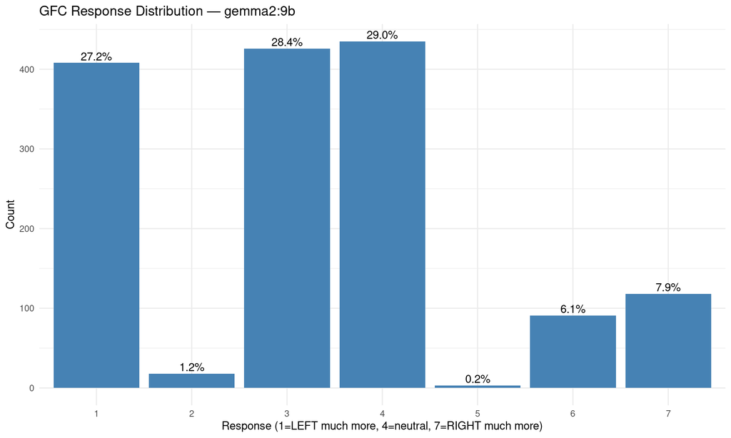

```r
all_results %>%
  filter(!is.na(response_argmax)) %>%
  count(response_argmax) %>%
  mutate(pct = n / sum(n) * 100) %>%
  ggplot(aes(x = response_argmax, y = n)) +
  geom_col(fill = "steelblue") +
  geom_text(aes(label = sprintf("%.1f%%", pct)), vjust = -0.3) +
  labs(title = paste("GFC Response Distribution —", model_name),
       x = "Response (1=LEFT much more, 4=neutral, 7=RIGHT much more)",
       y = "Count") +
  theme_minimal()
```

```r
all_results %>%
  filter(!is.na(response_entropy)) %>%
  summarise(
    n = n(),
    mean_ev = mean(response_ev, na.rm = TRUE),
    sd_ev = sd(response_ev, na.rm = TRUE),
    mean_entropy = mean(response_entropy, na.rm = TRUE),
    sd_entropy = sd(response_entropy, na.rm = TRUE)
  ) %>%
  knitr::kable(digits = 3, caption = "GFC response summary")
```

GFC response summary

| n | mean_ev | sd_ev | mean_entropy | sd_entropy |
| --- | --- | --- | --- | --- |
| 1499 | 3.317 | 1.427 | 0.728 | 0.437 |

```r
# Between-persona variation by block
block_var <- all_results %>%
  filter(!is.na(response_argmax)) %>%
  group_by(block) %>%
  summarise(
    mean = mean(as.numeric(response_argmax)),
    sd = sd(as.numeric(response_argmax)),
    n_cats = n_distinct(response_argmax),
    .groups = "drop"
  )

cat("Per-block variance summary:\n")
```

```
## Per-block variance summary:
```

```r
cat("  Mean SD:", round(mean(block_var$sd), 3), "\n")
```

```
##   Mean SD: 1.637
```

```r
cat("  Range SD:", round(min(block_var$sd), 3), "-", round(max(block_var$sd), 3), "\n")
```

```
##   Range SD: 0.35 - 2.986
```

```r
cat("  Low-variance blocks (SD < 0.5):\n")
```

```
##   Low-variance blocks (SD < 0.5):
```

```r
block_var %>% filter(sd < 0.5) %>%
  mutate(across(c(mean, sd), ~round(., 3))) %>%
  print()
```

```
## # A tibble: 1 × 4
##   block  mean    sd n_cats
##   <int> <dbl> <dbl>  <int>
## 1    21     3  0.35      3
```

## 3. Prepare Data

```r
instrument <- jsonlite::fromJSON("../instruments/okada_gfc30.json")
pairs <- instrument$pairs

pair_meta <- tibble(
  block = pairs$block,
  left_trait = pairs$left$trait,
  left_keying = pairs$left$keying,
  left_text = pairs$left$text,
  right_trait = pairs$right$trait,
  right_keying = pairs$right$keying,
  right_text = pairs$right$text,
  delta_sd = pairs$delta_sd
)

# Wide response matrix
response_wide <- all_results %>%
  filter(!is.na(response_argmax)) %>%
  select(persona_id, block, response_argmax) %>%
  pivot_wider(names_from = block, names_prefix = "b",
              values_from = response_argmax)

complete_mask <- complete.cases(response_wide[, -1])
cat("Complete respondents:", sum(complete_mask), "out of", nrow(response_wide), "\n")
```

```
## Complete respondents: 49 out of 50
```

## 4. Dimensionality Analysis

Before attempting TIRT (which assumes 5-factor structure), check whether the data actually supports 5 factors.

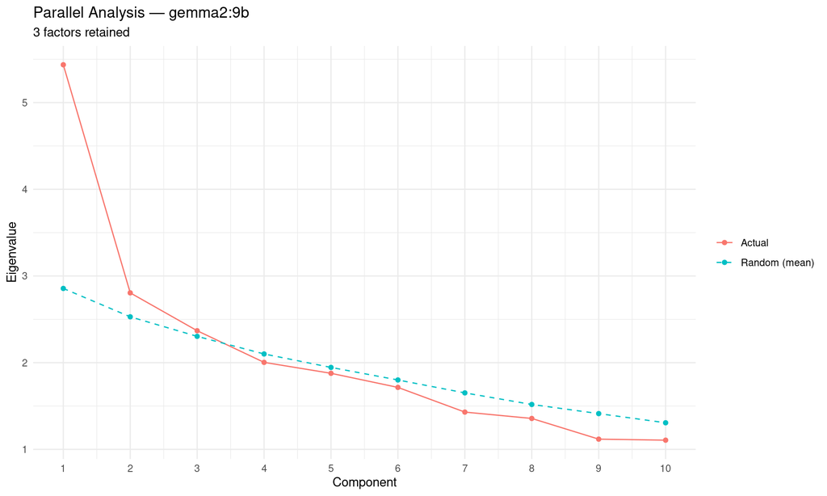

```r
resp <- response_wide[complete_mask, -1] %>%
  mutate(across(everything(), as.numeric))

# Eigenvalues of correlation matrix
R <- cor(resp)
eigs <- eigen(R)$values

# Parallel analysis
set.seed(42)
n_sim <- 100
n <- nrow(resp); p <- ncol(resp)
random_eigs <- matrix(0, n_sim, p)
for (s in 1:n_sim) {
  random_eigs[s,] <- eigen(cor(matrix(rnorm(n * p), n, p)))$values
}
mean_random <- colMeans(random_eigs)
n_factors <- sum(eigs > mean_random)

tibble(
  component = 1:10,
  eigenvalue = eigs[1:10],
  random_95 = mean_random[1:10],
  retain = eigs[1:10] > mean_random[1:10]
) %>%
  ggplot(aes(x = component)) +
  geom_line(aes(y = eigenvalue, color = "Actual")) +
  geom_point(aes(y = eigenvalue, color = "Actual")) +
  geom_line(aes(y = random_95, color = "Random (mean)"), linetype = "dashed") +
  geom_point(aes(y = random_95, color = "Random (mean)")) +
  scale_x_continuous(breaks = 1:10) +
  labs(title = paste("Parallel Analysis —", model_name),
       subtitle = paste(n_factors, "factors retained"),
       x = "Component", y = "Eigenvalue", color = NULL) +
  theme_minimal()
```

```r
cat("Factors retained by parallel analysis:", n_factors, "\n")
```

```
## Factors retained by parallel analysis: 3
```

```r
cat("Variance explained by first 5 factors:",
    round(sum(eigs[1:5]) / sum(eigs) * 100, 1), "%\n")
```

```
## Variance explained by first 5 factors: 48.3 %
```

**Interpretation:** With 3 factors retained, the 5-factor TIRT CFA model may be overparameterized for this data. This is likely because 50 personas from a single LLM do not generate enough multidimensional trait variation — between-persona differences are dominated by 1–3 dimensions rather than 5 independent Big Five factors.

## 5. Simple Scoring

For each GFC pair, the response direction and magnitude indicate relative trait preference. We convert each response to per-trait endorsement evidence:

- Response > 4: endorses RIGHT trait, dis-endorses LEFT trait
- Response < 4: endorses LEFT trait, dis-endorses RIGHT trait
- Response = 4: neutral

Keying is applied: negatively-keyed items reverse the trait direction.

```r
trait_evidence <- all_results %>%
  filter(!is.na(response_argmax)) %>%
  mutate(
    resp_val = coalesce(as.numeric(response_ev), as.numeric(response_argmax)),
    pref = resp_val - 4,
    right_endorsement = pref * ifelse(right_keying == "+", 1, -1),
    left_endorsement = -pref * ifelse(left_keying == "+", 1, -1)
  )

trait_scores_simple <- bind_rows(
  trait_evidence %>%
    select(persona_id, trait = right_trait, endorsement = right_endorsement),
  trait_evidence %>%
    select(persona_id, trait = left_trait, endorsement = left_endorsement)
) %>%
  group_by(persona_id, trait) %>%
  summarise(score = mean(endorsement, na.rm = TRUE), .groups = "drop")

simple_wide <- trait_scores_simple %>%
  pivot_wider(names_from = trait, values_from = score)
```

```r
traits <- c("A", "C", "E", "N", "O")
trait_labels <- c(A = "Agreeableness", C = "Conscientiousness",
                  E = "Extraversion", N = "Neuroticism", O = "Openness")

cat("Simple trait score summary:\n")
```

```
## Simple trait score summary:
```

```r
for (t in traits) {
  cat(sprintf("  %s (%s): mean=%.3f  sd=%.3f  range=[%.3f, %.3f]\n",
              t, trait_labels[t],
              mean(simple_wide[[t]]), sd(simple_wide[[t]]),
              min(simple_wide[[t]]), max(simple_wide[[t]])))
}
```

```
##   A (Agreeableness): mean=0.597  sd=0.488  range=[-0.624, 1.480]
##   C (Conscientiousness): mean=0.116  sd=0.401  range=[-0.630, 1.200]
##   E (Extraversion): mean=-0.755  sd=0.452  range=[-1.698, 0.654]
##   N (Neuroticism): mean=-0.056  sd=0.351  range=[-1.065, 0.637]
##   O (Openness): mean=-0.014  sd=0.405  range=[-1.630, 0.866]
```

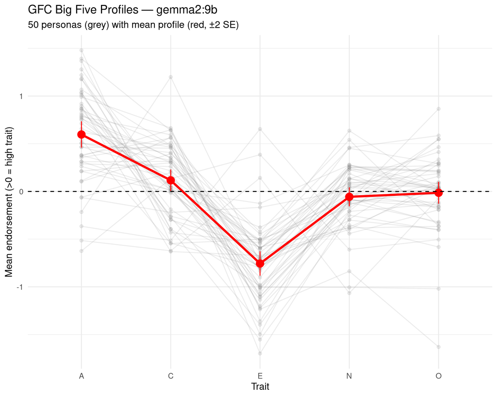

```r
# Mean profile
mean_profile <- trait_scores_simple %>%
  group_by(trait) %>%
  summarise(mean = mean(score), se = sd(score) / sqrt(n()), .groups = "drop")

# Individual profiles + mean
ggplot() +
  geom_line(data = trait_scores_simple,
            aes(x = trait, y = score, group = persona_id),
            alpha = 0.15, color = "grey50") +
  geom_point(data = trait_scores_simple,
             aes(x = trait, y = score, group = persona_id),
             alpha = 0.15, color = "grey50") +
  geom_line(data = mean_profile,
            aes(x = trait, y = mean, group = 1),
            color = "red", linewidth = 1.5) +
  geom_pointrange(data = mean_profile,
                  aes(x = trait, y = mean,
                      ymin = mean - 2*se, ymax = mean + 2*se),
                  color = "red", size = 1) +
  geom_hline(yintercept = 0, linetype = "dashed") +
  labs(title = paste("GFC Big Five Profiles —", model_name),
       subtitle = paste(n_distinct(trait_scores_simple$persona_id),
                        "personas (grey) with mean profile (red, ±2 SE)"),
       x = "Trait", y = "Mean endorsement (>0 = high trait)") +
  theme_minimal(base_size = 14)
```

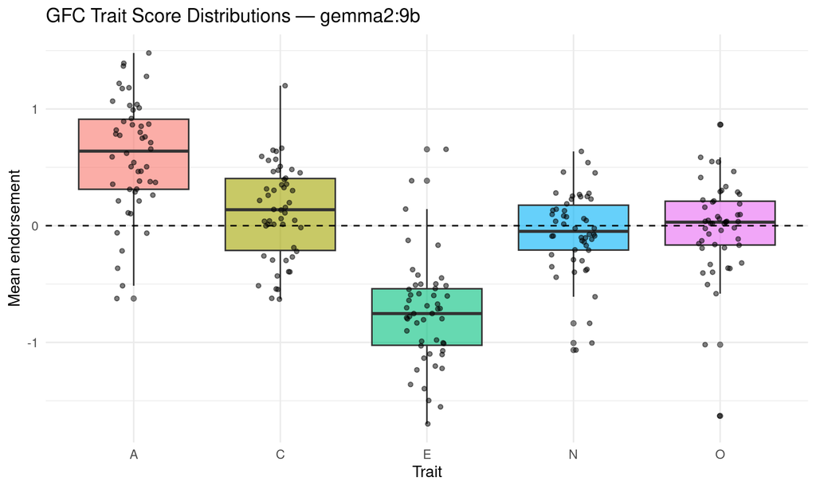

```r
trait_scores_simple %>%
  mutate(trait_label = trait_labels[trait]) %>%
  ggplot(aes(x = trait, y = score, fill = trait)) +
  geom_boxplot(alpha = 0.6) +
  geom_jitter(width = 0.15, alpha = 0.5, size = 1.5) +
  geom_hline(yintercept = 0, linetype = "dashed") +
  labs(title = paste("GFC Trait Score Distributions —", model_name),
       x = "Trait", y = "Mean endorsement") +
  theme_minimal(base_size = 14) +
  theme(legend.position = "none")
```

```r
cat("Trait score correlations (simple scoring):\n")
```

```
## Trait score correlations (simple scoring):
```

```r
print(round(cor(simple_wide[, traits]), 3))
```

```
##        A      C      E      N      O
## A  1.000 -0.179 -0.603  0.230 -0.160
## C -0.179  1.000 -0.348  0.154 -0.255
## E -0.603 -0.348  1.000 -0.069 -0.100
## N  0.230  0.154 -0.069  1.000  0.512
## O -0.160 -0.255 -0.100  0.512  1.000
```

## 6. TIRT CFA (Exploratory)

Attempting the full 5-factor Thurstonian IRT CFA as a confirmatory check. With the parallel analysis showing 3 factors, this is expected to have identification issues.

```r
# Build column names matching TIRT convention
pairwise_data <- data.frame(person = seq_len(nrow(response_wide)))
item_names <- list()
for (i in seq_len(nrow(pairs))) {
  left_name <- paste0(pairs$left$trait[i],
                       ifelse(pairs$left$keying[i] == "+", "p", "n"), i)
  right_name <- paste0(pairs$right$trait[i],
                        ifelse(pairs$right$keying[i] == "+", "p", "n"), i)
  col_name <- paste0(left_name, right_name)
  pairwise_data[[col_name]] <- as.numeric(response_wide[[paste0("b", i)]])
  item_names[[i]] <- list(left = left_name, right = right_name, col = col_name)
}

pw_complete <- pairwise_data[complete_mask, ]
pw_complete$person <- seq_len(nrow(pw_complete))

inv_sqrt2 <- 1 / sqrt(2)
loadings <- character()
for (i in seq_len(nrow(pairs))) {
  col_name <- item_names[[i]]$col
  lt <- pairs$left$trait[i]; rt <- pairs$right$trait[i]
  ls <- ifelse(pairs$left$keying[i] == "+", 1, -1)
  rs <- ifelse(pairs$right$keying[i] == "+", 1, -1)
  loadings <- c(loadings,
                paste0(rt, " =~ ", round(rs * inv_sqrt2, 4), "*", col_name))
  loadings <- c(loadings,
                paste0(lt, " =~ ", round(-ls * inv_sqrt2, 4), "*", col_name))
}

model_syntax <- paste(c(
  loadings,
  paste0(traits, " ~~ 1*", traits),
  paste0(traits, " ~ 0*1"),
  {cor_lines <- character()
   for (i in 1:4) for (j in (i+1):5)
     cor_lines <- c(cor_lines, paste0(traits[i], " ~~ ", traits[j]))
   cor_lines}
), collapse = "\n")

# Try continuous ML (ordinal WLSMV fails with sparse categories)
fit_ml <- tryCatch({
  sem(model_syntax, data = pw_complete[, -1], std.lv = TRUE, estimator = "ML")
}, error = function(e) NULL)
if (!is.null(fit_ml) && lavInspect(fit_ml, "converged")) {
  cat("ML fit converged\n")
  cov_lv <- lavInspect(fit_ml, "cov.lv")
  eig_lv <- eigen(cov_lv)$values

  cat("\nLatent covariance matrix eigenvalues:", round(eig_lv, 4), "\n")
  cat("Positive definite:", all(eig_lv > 0), "\n")

  if (any(eig_lv <= 0)) {
    cat("\nWARNING: Latent covariance matrix is NOT positive definite.\n")
    cat("This Heywood case indicates the 5-factor structure is not supported.\n")
    cat("Off-diagonal correlations:\n")
    dimnames(cov_lv) <- list(traits, traits)
    print(round(cov2cor(cov_lv), 3))
  }

  fitmeas <- fitmeasures(fit_ml, c("chisq", "df", "pvalue", "cfi", "tli", "rmsea"))
  cat("\nFit indices:\n")
  print(round(fitmeas, 3))
} else {
  cat("TIRT CFA did not converge. See dimensionality analysis above.\n")
}
```

```
## ML fit converged
##
## Latent covariance matrix eigenvalues: 4.7909 0.5205 -0.0064 -0.1028 -0.2021
## Positive definite: FALSE
##
## WARNING: Latent covariance matrix is NOT positive definite.
## This Heywood case indicates the 5-factor structure is not supported.
## Off-diagonal correlations:
##        A      C      E      N      O
## A  1.000
## C  0.502  1.000
## E  0.951  0.773  1.000
## N  1.084  0.864  1.128  1.000
## O -1.041 -0.852 -1.071 -1.111  1.000
##
## Fit indices:
##   chisq      df  pvalue     cfi     tli   rmsea
## 785.947 425.000   0.000   0.165   0.145   0.132
```

**Note on TIRT CFA limitations with single-model data:** The TIRT CFA with fixed loadings (±1/√2) assumes 5 independent trait dimensions and equal item discrimination. With 50 personas from a single LLM, between-persona variation is insufficiently multidimensional (parallel analysis retains 3 factors). The resulting latent covariance matrix has near-unit or super-unit off-diagonal elements and negative eigenvalues, indicating a Heywood case.

Options for improving the CFA:

1. **Multi-model data**: Pool personas across models to increase dimensional variation (different models may vary on different trait dimensions).
2. **Free discrimination parameters**: Okada’s Stan model freely estimates $a_j^+$ per statement rather than fixing all loadings equal.
3. **Bayesian regularization**: Stan with informative priors on correlations (e.g., LKJ prior) prevents Heywood cases.

## 7. Comparison: GFC vs Likert “Assistant Shape”

```r
# The "assistant shape" from Likert: high A, high C, high O, low N
# Does GFC show the same pattern?

cat("GFC mean profile (simple scoring):\n")
```

```
## GFC mean profile (simple scoring):
```

```r
mean_profile %>%
  mutate(
    direction = ifelse(mean > 0, "above neutral", "below neutral"),
    assistant_shape = c("HIGH", "HIGH", "varies", "LOW", "HIGH")
  ) %>%
  knitr::kable(digits = 3,
               caption = "GFC profile vs expected 'assistant shape'")
```

GFC profile vs expected ‘assistant shape’

| trait | mean | se | direction | assistant_shape |
| --- | --- | --- | --- | --- |
| A | 0.597 | 0.069 | above neutral | HIGH |
| C | 0.116 | 0.057 | above neutral | HIGH |
| E | -0.755 | 0.064 | below neutral | varies |
| N | -0.056 | 0.050 | below neutral | LOW |
| O | -0.014 | 0.057 | below neutral | HIGH |